# Final Project Milestone 5

Michael Wu

3/20/2020

### the Coronavirus Project.

With the WHO classifying the risk of the novel coronavirus to its highest levels today and public health magnates like Bill Gates calling the disease a pandemic, COVID-19 is both literally and figuratively unlike anything we have ever seen before.

The public response around the globe has been that of sheer panic, with ramifications of the disease rippling through all facets of society. Grocery store shelves in Italy have gone empty from the public’s fear of food shortages and quarantine, investors on Wall Street have been whipped into a near state of hysteria with the DJI losing 10% of its value in just six sessions – the quickest correction ever.

### New Updates for the Fifth Milestone

Hello! It’s been a bit of crazy week having to move back home from campus and get adjusted to the quarantine life, but I feel reasonably satisfied with my progress as of the fifth milestone. First, I have updated the datasets so that they are in line with the most updated realtime data from the John Hopkins GitHub page. I have also created three separate graphs that plot the case numbers in the most affected countries and also the most affected provinces and states within China and US (wherever there’s province/state data).

Something really simple that I think would be interesting is to somehow also factor in each country’s overall population so we can see if larger provinces, states, or countries experience more rapid case growth. I’m still working on obtaining the previous flu data from the WHO and will try to get that up and running next week. Please let me know if you have any general pieces of feedback!

### Preliminary Plots for the Coronavirus Outbreak

$~$

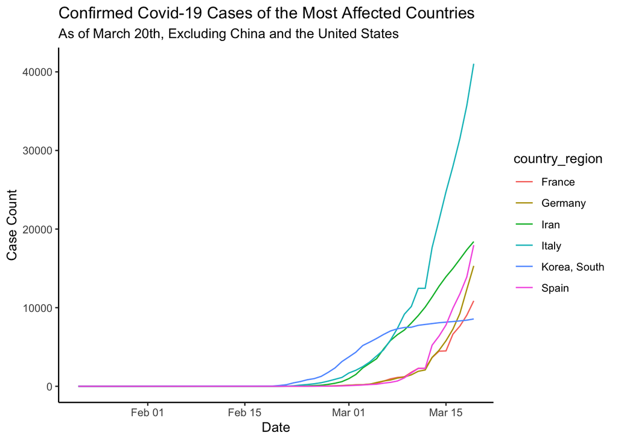

[figure not shown]

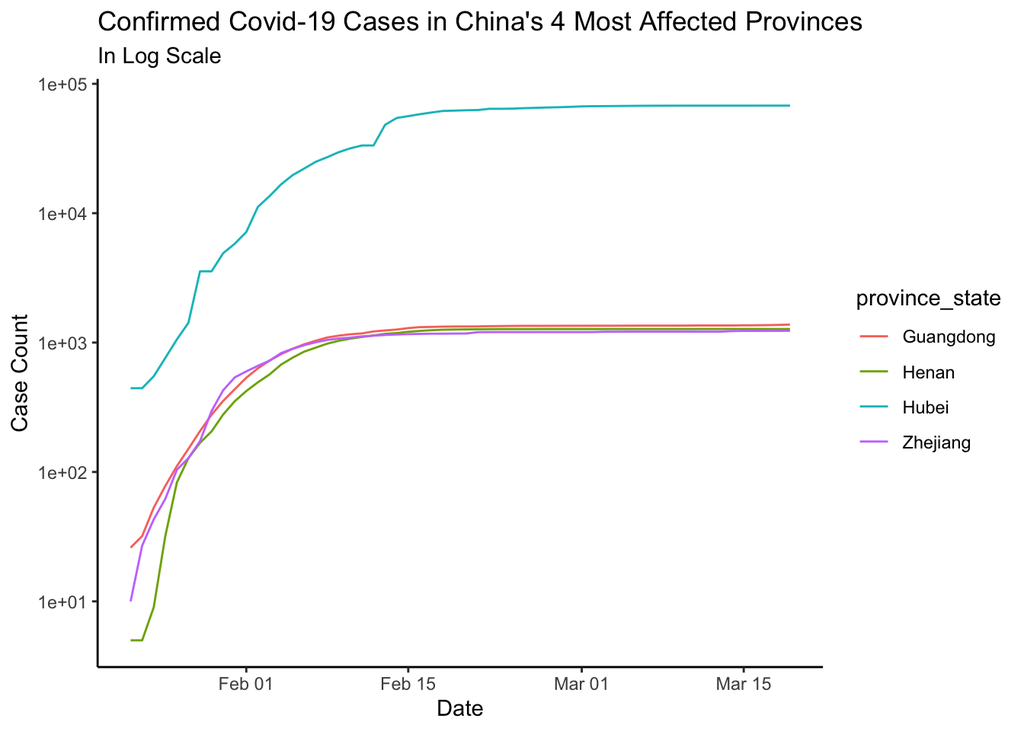

$~$

$~$